# Measuring Ecological Intelligence on Business Students

2025-05-10

## 1 Intelligence Scale

Ecological intelligence aims to develop social and environmental responsability and awareness, to think critically, to pursue cooperative learning, and to bring about behavioral change in the long-term.

Ecological intelligence should have a holistic perspective because there are seen and unseen webs among biotic and abiotic factors in the world. According to the model of Okur-Berberoglu (2020), social intelligence and economy are subsets of ecological intelligence. Social intelligence refers to social responsibilities of people in terms of sustainability. Economy should be based on sustainable development instead of explotation of environmental and human resources.

Okur-Berberoglu (2020) developed a scale for ecological intelligence. The questionnaire consists of 12 questions based on a 5 Likert scale that were scored as 1-Completely disagree, 2-Partly disagree, 3-Not sure, 4-Partly agree, and 5-Completely agree. The questions were the following.  
1. I get my full water bottle while leaving home.  
2. I wonder about increasing of cancer events in industrial areas.  
3. Degenerated environmental conditions can cause negative effect on mental health.  
4. What a pitty!, people think that technology can solve every problem, althought technology cannot produce one gram organic honey.  
5. The reflection of environmental problems can be seen at the same time, in succession, and more than one area.  
6. I try to pattern people who have positive ecologic behavior in my social life.  
7. I prefer to buy local vegetables and fruits.  
8. I believe that one of the ways of fighting with obesity is environmental education.  
9. I have remorse to know some goods I buy, are produced by explotation of human work.  
10. One of the reasons of immigration of rural people, is the job lost due to global firms.  
11. Global firms prevent local producer to have profit.  
12. People, to immigrate to another place, are cheaper laborer sources for big companies.

This scale was based on Turkey and Turkish lifestyle, as the author comment in his work this scale should the tested and understood by other researchers.

## 2 Survey Data

```r
data_file_path <- here::here("data", "Ecologial Scale - Raw Data.xlsx")
#dfenc <- read.xlsx(xlsxFile = "./data/Ecologial Scale - Raw Data.xlsx",
#                     sheet = "Ecological Inteligence Scale", colNames=TRUE) %>%
dfenc <- read.xlsx(xlsxFile = data_file_path) %>%
  mutate(Username = seq(1,n())) %>%
  na.omit()
colnames(dfenc) <- c("date", "student", "campus", "genre", "nationality", "age", paste0("holis", 1:5), paste0("social", 1:4), paste0("econ",1:3), "change", "argument")
dfenc$campus <- substr(dfenc$campus, 8, 50)
for (i in 7:18) {
  dfenc[,i] <- recode(dfenc[,i], `Completely agree`=5,
                      `Partly agree`=4,
                      `Not sure`=3,
                      `Partly disagree`=2,
                      `Completely disagree`=1)
}
```

```r
dfdemo <- select(dfenc, student:age)

countvals <- function(x, categ) {return(sum(x==categ))}
agetags <- sort(unique(dfenc$age))

tbdesc <- dfdemo %>%
  group_by(campus) %>%
  summarise(N = n(),
            Hombre = countvals(genre, "Hombre"),
            Mujer = countvals(genre, "Mujer"),
            USA = countvals(nationality, "Estadounidense"),
            Mexico = countvals(nationality, "Mexicana"),
            Otro = countvals(nationality, "Otra"),
            E21_22 = countvals(age, agetags[1]),
            E23_24 = countvals(age, agetags[2]),
            E25omas = countvals(age, agetags[3]))

kbl(tbdesc) %>%
  kable_classic(full_width=FALSE) %>%
  add_header_above(c(" "=2, "Sex"=2, "Country"=3, "Age"=3))
```

| campus | N | Sex Hombre | Sex Mujer | Country USA | Country Mexico | Country Otro | Age E21_22 | Age E23_24 | Age E25omas |
| --- | --- | --- | --- | --- | --- | --- | --- | --- | --- |
| Aguascalientes | 7 | 4 | 3 | 0 | 7 | 0 | 4 | 3 | 0 |
| Guadalajara | 53 | 27 | 26 | 1 | 49 | 3 | 37 | 16 | 0 |
| Morelia | 3 | 2 | 1 | 0 | 3 | 0 | 1 | 2 | 0 |
| Sinaloa | 19 | 10 | 9 | 0 | 19 | 0 | 12 | 6 | 1 |

## 3 Descriptive

Now we compute the indicators and its statistics.

```r
dfenc$campus[dfenc$campus == "Aguascalientes"] <- "Otro"
dfenc$campus[dfenc$campus == "Morelia"] <- "Otro"

options(width=200)
dfenc <- dfenc %>%
  mutate(holis = (holis1+holis2+holis3+holis4+holis5)/5,
         social = (social1+social2+social3+social4)/4,
         econ = (econ1+econ2+econ3)/3)
psych::describe(select(dfenc,holis:econ, change))
```

```
##        vars  n mean   sd median trimmed  mad  min max range  skew kurtosis   se
## holis     1 82 4.12 0.55    4.2    4.13 0.59 2.60   5  2.40 -0.24    -0.39 0.06
## social    2 82 4.00 0.66    4.0    4.03 0.74 2.00   5  3.00 -0.42    -0.29 0.07
## econ      3 82 3.96 0.66    4.0    3.97 0.49 2.33   5  2.67 -0.26    -0.43 0.07
## change    4 82 8.51 1.37    9.0    8.70 1.48 3.00  10  7.00 -1.27     2.24 0.15
```

Let us obtain the correlation matrix and their corresponding p-values.

```r
rcorr(as.matrix(select(dfenc,holis1:econ3)))
```

```
##         holis1 holis2 holis3 holis4 holis5 social1 social2 social3 social4 econ1 econ2 econ3
## holis1    1.00   0.25   0.09  -0.02   0.17    0.22    0.24    0.18    0.04  0.15 -0.02  0.00
## holis2    0.25   1.00   0.22   0.25   0.20    0.41    0.22    0.42    0.21  0.39  0.28  0.12
## holis3    0.09   0.22   1.00   0.08   0.25    0.32    0.11    0.31    0.16  0.21  0.21  0.16
## holis4   -0.02   0.25   0.08   1.00   0.22    0.29    0.21    0.26    0.18  0.13  0.23  0.33
## holis5    0.17   0.20   0.25   0.22   1.00    0.19    0.11    0.32    0.04  0.13  0.24  0.07
## social1   0.22   0.41   0.32   0.29   0.19    1.00    0.57    0.15    0.48  0.31  0.09  0.23
## social2   0.24   0.22   0.11   0.21   0.11    0.57    1.00    0.09    0.41  0.14  0.07  0.15
## social3   0.18   0.42   0.31   0.26   0.32    0.15    0.09    1.00    0.15  0.42  0.33  0.25
## social4   0.04   0.21   0.16   0.18   0.04    0.48    0.41    0.15    1.00  0.42  0.02  0.37
## econ1     0.15   0.39   0.21   0.13   0.13    0.31    0.14    0.42    0.42  1.00  0.21  0.38
## econ2    -0.02   0.28   0.21   0.23   0.24    0.09    0.07    0.33    0.02  0.21  1.00  0.24
## econ3     0.00   0.12   0.16   0.33   0.07    0.23    0.15    0.25    0.37  0.38  0.24  1.00
##
## n= 82
##
##
## P
##         holis1 holis2 holis3 holis4 holis5 social1 social2 social3 social4 econ1  econ2  econ3
## holis1         0.0211 0.4004 0.8883 0.1198 0.0452  0.0330  0.1065  0.7542  0.1672 0.8703 1.0000
## holis2  0.0211        0.0505 0.0239 0.0731 0.0001  0.0498  0.0000  0.0612  0.0003 0.0114 0.2810
## holis3  0.4004 0.0505        0.4583 0.0236 0.0034  0.3327  0.0046  0.1527  0.0564 0.0643 0.1582
## holis4  0.8883 0.0239 0.4583        0.0435 0.0092  0.0578  0.0162  0.0970  0.2297 0.0379 0.0022
## holis5  0.1198 0.0731 0.0236 0.0435        0.0830  0.3270  0.0031  0.7364  0.2538 0.0281 0.5369
## social1 0.0452 0.0001 0.0034 0.0092 0.0830         0.0000  0.1701  0.0000  0.0042 0.4059 0.0413
## social2 0.0330 0.0498 0.3327 0.0578 0.3270 0.0000          0.4084  0.0001  0.2240 0.5221 0.1654
## social3 0.1065 0.0000 0.0046 0.0162 0.0031 0.1701  0.4084          0.1871  0.0000 0.0024 0.0224
## social4 0.7542 0.0612 0.1527 0.0970 0.7364 0.0000  0.0001  0.1871          0.0000 0.8438 0.0006
## econ1   0.1672 0.0003 0.0564 0.2297 0.2538 0.0042  0.2240  0.0000  0.0000         0.0561 0.0004
## econ2   0.8703 0.0114 0.0643 0.0379 0.0281 0.4059  0.5221  0.0024  0.8438  0.0561        0.0278
## econ3   1.0000 0.2810 0.1582 0.0022 0.5369 0.0413  0.1654  0.0224  0.0006  0.0004 0.0278
```

## 4 Cronbach’s alpha

When items are used to form a scale they eed to have internal consistency. The items should all measure the same thing, so they should be correlated with on another. A useful coefficient for assessing internal consistency is Cronbach’s alpha. The formula is:
$$\alpha = \frac{k}{k-1} \left( 1-\frac{\sum s_i^2}{s_T^2} \right)$$
where $k$ is the number of items, $s_i^2$ is the variance of the ith item and $s_T^2$ is the variance of the total score formed by summing all the items. If the items are all independent, then $\alpha =0$. If the items are all identical and so perfectly correlated, then $\alpha = 1$.

```r
psych::alpha(select(dfenc, holis1:econ3))
```

```
##
## Reliability analysis
## Call: psych::alpha(x = select(dfenc, holis1:econ3))
##
##   raw_alpha std.alpha G6(smc) average_r S/N   ase mean  sd median_r
##       0.76      0.77     0.8      0.22 3.3 0.038    4 0.5     0.21
##
##     95% confidence boundaries
##          lower alpha upper
## Feldt     0.68  0.76  0.83
## Duhachek  0.69  0.76  0.84
##
##  Reliability if an item is dropped:
##         raw_alpha std.alpha G6(smc) average_r S/N alpha se var.r med.r
## holis1       0.77      0.77    0.80      0.24 3.4    0.037 0.014  0.22
## holis2       0.73      0.74    0.77      0.21 2.9    0.044 0.016  0.21
## holis3       0.75      0.76    0.79      0.22 3.1    0.040 0.017  0.22
## holis4       0.75      0.76    0.79      0.22 3.1    0.040 0.017  0.21
## holis5       0.75      0.76    0.79      0.22 3.2    0.040 0.017  0.22
## social1      0.73      0.73    0.76      0.20 2.8    0.044 0.013  0.21
## social2      0.75      0.75    0.78      0.22 3.1    0.041 0.014  0.22
## social3      0.73      0.74    0.77      0.21 2.9    0.043 0.016  0.21
## social4      0.74      0.75    0.78      0.21 3.0    0.041 0.013  0.22
## econ1        0.73      0.74    0.77      0.21 2.9    0.043 0.015  0.21
## econ2        0.75      0.76    0.79      0.23 3.2    0.040 0.016  0.21
## econ3        0.75      0.75    0.78      0.22 3.1    0.041 0.016  0.21
##
##  Item statistics
##          n raw.r std.r r.cor r.drop mean   sd
## holis1  82  0.40  0.36  0.26   0.22  4.2 1.18
## holis2  82  0.64  0.62  0.58   0.52  3.6 1.09
## holis3  82  0.43  0.49  0.41   0.35  4.6 0.58
## holis4  82  0.52  0.50  0.43   0.36  3.9 1.10
## holis5  82  0.44  0.46  0.38   0.33  4.3 0.76
## social1 82  0.66  0.67  0.67   0.56  4.1 0.87
## social2 82  0.53  0.52  0.48   0.39  4.3 1.02
## social3 82  0.63  0.61  0.58   0.49  3.6 1.14
## social4 82  0.53  0.55  0.51   0.42  4.1 0.84
## econ1   82  0.62  0.61  0.58   0.50  3.9 0.99
## econ2   82  0.44  0.46  0.37   0.32  4.0 0.81
## econ3   82  0.52  0.52  0.46   0.39  4.0 0.94
##
## Non missing response frequency for each item
##            1    2    3    4    5 miss
## holis1  0.05 0.09 0.06 0.23 0.57    0
## holis2  0.05 0.07 0.35 0.28 0.24    0
## holis3  0.00 0.00 0.05 0.29 0.66    0
## holis4  0.04 0.09 0.21 0.33 0.34    0
## holis5  0.01 0.00 0.10 0.41 0.48    0
## social1 0.01 0.04 0.15 0.45 0.35    0
## social2 0.04 0.02 0.12 0.28 0.54    0
## social3 0.07 0.09 0.24 0.38 0.22    0
## social4 0.00 0.04 0.21 0.40 0.35    0
## econ1   0.04 0.04 0.21 0.43 0.29    0
## econ2   0.00 0.06 0.16 0.54 0.24    0
## econ3   0.01 0.06 0.18 0.40 0.34    0
```

```r
psych::alpha(select(dfenc, holis1:holis5))
```

```
##
## Reliability analysis
## Call: psych::alpha(x = select(dfenc, holis1:holis5))
##
##   raw_alpha std.alpha G6(smc) average_r S/N   ase mean   sd median_r
##       0.48      0.51    0.48      0.17   1 0.088  4.1 0.55     0.21
##
##     95% confidence boundaries
##          lower alpha upper
## Feldt     0.28  0.48  0.64
## Duhachek  0.31  0.48  0.66
##
##  Reliability if an item is dropped:
##        raw_alpha std.alpha G6(smc) average_r  S/N alpha se  var.r med.r
## holis1      0.49      0.51    0.44      0.20 1.02    0.088 0.0039  0.22
## holis2      0.32      0.38    0.34      0.13 0.62    0.122 0.0099  0.13
## holis3      0.45      0.47    0.42      0.18 0.88    0.099 0.0102  0.21
## holis4      0.47      0.50    0.43      0.20 0.99    0.090 0.0035  0.21
## holis5      0.39      0.41    0.37      0.15 0.69    0.106 0.0120  0.16
##
##  Item statistics
##         n raw.r std.r r.cor r.drop mean   sd
## holis1 82  0.59  0.52  0.30   0.20  4.2 1.18
## holis2 82  0.70  0.66  0.54   0.40  3.6 1.09
## holis3 82  0.44  0.57  0.37   0.24  4.6 0.58
## holis4 82  0.57  0.53  0.32   0.20  3.9 1.10
## holis5 82  0.57  0.63  0.49   0.34  4.3 0.76
##
## Non missing response frequency for each item
##           1    2    3    4    5 miss
## holis1 0.05 0.09 0.06 0.23 0.57    0
## holis2 0.05 0.07 0.35 0.28 0.24    0
## holis3 0.00 0.00 0.05 0.29 0.66    0
## holis4 0.04 0.09 0.21 0.33 0.34    0
## holis5 0.01 0.00 0.10 0.41 0.48    0
```

```r
psych::alpha(select(dfenc, social1:social4))
```

```
##
## Reliability analysis
## Call: psych::alpha(x = select(dfenc, social1:social4))
##
##   raw_alpha std.alpha G6(smc) average_r S/N   ase mean   sd median_r
##       0.61      0.64    0.62      0.31 1.8 0.072    4 0.66     0.28
##
##     95% confidence boundaries
##          lower alpha upper
## Feldt     0.45  0.61  0.73
## Duhachek  0.47  0.61  0.75
##
##  Reliability if an item is dropped:
##         raw_alpha std.alpha G6(smc) average_r  S/N alpha se  var.r med.r
## social1      0.42      0.45    0.39      0.22 0.83     0.11 0.0289  0.15
## social2      0.48      0.51    0.45      0.26 1.05     0.10 0.0360  0.15
## social3      0.74      0.74    0.66      0.49 2.85     0.05 0.0066  0.48
## social4      0.50      0.53    0.50      0.27 1.12     0.10 0.0683  0.15
##
##  Item statistics
##          n raw.r std.r r.cor r.drop mean   sd
## social1 82  0.77  0.79  0.74   0.56  4.1 0.87
## social2 82  0.74  0.75  0.65   0.47  4.3 1.02
## social3 82  0.56  0.50  0.19   0.16  3.6 1.14
## social4 82  0.70  0.73  0.60   0.47  4.1 0.84
##
## Non missing response frequency for each item
##            1    2    3    4    5 miss
## social1 0.01 0.04 0.15 0.45 0.35    0
## social2 0.04 0.02 0.12 0.28 0.54    0
## social3 0.07 0.09 0.24 0.38 0.22    0
## social4 0.00 0.04 0.21 0.40 0.35    0
```

```r
psych::alpha(select(dfenc, econ1:econ3))
```

```
##
## Reliability analysis
## Call: psych::alpha(x = select(dfenc, econ1:econ3))
##
##   raw_alpha std.alpha G6(smc) average_r S/N   ase mean   sd median_r
##       0.54      0.54    0.45      0.28 1.2 0.086    4 0.66     0.24
##
##     95% confidence boundaries
##          lower alpha upper
## Feldt     0.34  0.54  0.69
## Duhachek  0.37  0.54  0.71
##
##  Reliability if an item is dropped:
##       raw_alpha std.alpha G6(smc) average_r  S/N alpha se var.r med.r
## econ1      0.39      0.39    0.24      0.24 0.64    0.134    NA  0.24
## econ2      0.55      0.55    0.38      0.38 1.25    0.098    NA  0.38
## econ3      0.34      0.35    0.21      0.21 0.54    0.142    NA  0.21
##
##  Item statistics
##        n raw.r std.r r.cor r.drop mean   sd
## econ1 82  0.77  0.74  0.52   0.39  3.9 0.99
## econ2 82  0.63  0.67  0.37   0.27  4.0 0.81
## econ3 82  0.76  0.75  0.55   0.41  4.0 0.94
##
## Non missing response frequency for each item
##          1    2    3    4    5 miss
## econ1 0.04 0.04 0.21 0.43 0.29    0
## econ2 0.00 0.06 0.16 0.54 0.24    0
## econ3 0.01 0.06 0.18 0.40 0.34    0
```

We also visualize the correlations with a heat map. We note that the correlations are low, so the instrument would not capture the construct properly.

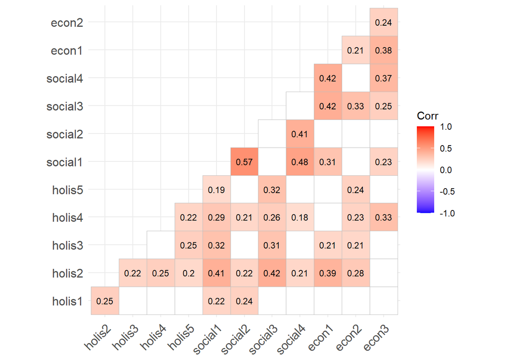

```r
p.mat <- cor_pmat(select(dfenc,holis1:econ3))
ggcorrplot(cor(select(dfenc,holis1:econ3)),
           type="lower",
           lab=TRUE,
           lab_size=3,
           insig="blank",
           p.mat=p.mat,
           sig.level=0.10)
```

Let us compare the dimensions by campus.

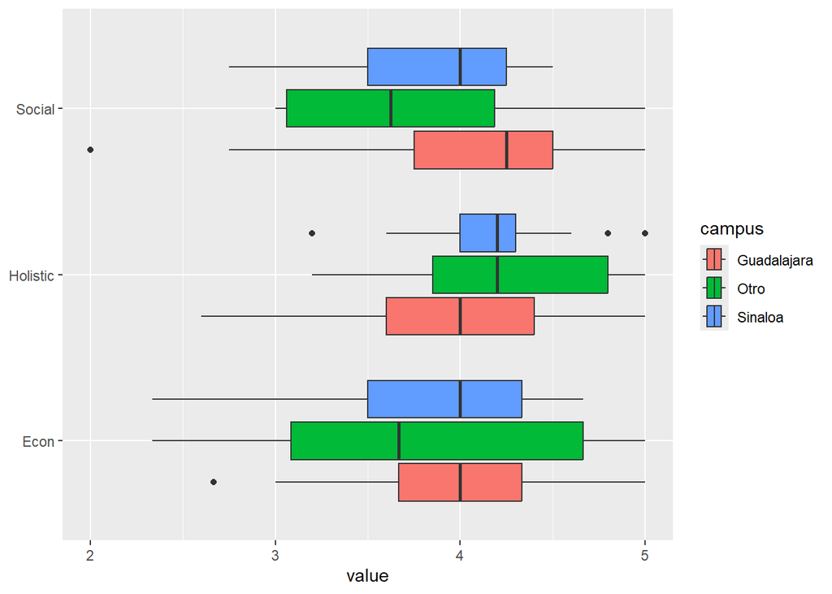

```r
stkfacts <- data.frame()
namefacts <- c("Holistic", "Social", "Econ")
tagfacts <- c("holis", "social", "econ")
for (i in 1:3) {
  dftmp <- data.frame(student = dfenc$student,
                      campus = dfenc$campus,
                      fact=rep(namefacts[i],nrow(dfenc)),
                      value = dfenc[, tagfacts[i]])
  stkfacts <- rbind(stkfacts, dftmp)
}

ggplot(stkfacts, aes(y=fact, x=value, fill=campus)) +
  geom_boxplot() +
  theme(axis.title.y = element_blank())
```

## 5 Kaiser-Meyer-Olkin (KMO) test

The KMO test is a statistical measure to determine how suited data is for factor analysis. The test measures sampling adequacy for each variable in the model and the complete model. The statistic is a measure of the proportion of variance among variables that might be common variance.

The MSA (Measure of Sampling Adequacy) criterion is calculated and return values between 0 and 1.
$$\hbox{MSA} = \frac{\sum_{j\neq k} r_{jk}^2}{\sum_{j\neq k} r_{jk}^2 +
\sum_{j\neq k} p_{jk}^2}$$
Here $r_{jk}$ is the correlation between the variable in question and another, and $p_{jk}$ is the partial correlation. KMO values between 0.8 and 1 indicate the sampling is adequate. KMO values less than 0.6 indicate the sampling is not adequate and that remedial action should be taken. In contrast, others set this cutoff value at 0.5. A KMO value close to zero means that there are large partial correlations compared to the sum of correlations. In other words, there are widespread correlations which would be a large problem for factor analysis.

```r
cor_matrix <- cor(select(dfenc,holis1:econ3))
KMO(cor_matrix)
```

```
## Kaiser-Meyer-Olkin factor adequacy
## Call: KMO(r = cor_matrix)
## Overall MSA =  0.74
## MSA for each item =
##  holis1  holis2  holis3  holis4  holis5 social1 social2 social3 social4   econ1   econ2   econ3
##    0.65    0.78    0.74    0.73    0.78    0.72    0.70    0.76    0.75    0.76    0.75    0.73
```

## 6 Bartlett’s test of sphericity

The Bartlett’s test is used to determine whether or not the data come from a multivariate normal distribution.

Let us suppose that $x_1, x_2, \dots$ are random vectors en $R^p$ having a multivariate normal distribution with unknown mean vector $\mu$ and unknown covariance matrix $\Sigma$. The hypothesis are
$H_o: \Sigma = \sigma I_p$
$H_a: \Sigma \neq \sigma I_p$, $\Sigma$ positive definite
$\alpha = 0.05$
The test statistic is
$$T_0 = \frac{(\hbox{tr}\ S)^p}{|S|}.$$

```
## $chisq
## [1] 213.8169
##
## $p.value
## [1] 1.700443e-17
##
## $df
## [1] 66
```

## 7 Confirmatory analysis

```r
dfitems <- select(dfenc, holis1:econ3)
mla <- 'f1 =~ holis1 + holis2 + holis3 + holis4 + holis5
        f2 =~ social1 + social2 + social3 + social4
        f3 =~ econ1 + econ2 + econ3'
threef <- cfa(mla, data=dfitems, std.lv=TRUE)
summary(threef, fit.measures=TRUE, standardized=TRUE)
```

```
## lavaan 0.6-19 ended normally after 21 iterations
##
##   Estimator                                         ML
##   Optimization method                           NLMINB
##   Number of model parameters                        27
##
##   Number of observations                            82
##
## Model Test User Model:
##
##   Test statistic                                85.650
##   Degrees of freedom                                51
##   P-value (Chi-square)                           0.002
##
## Model Test Baseline Model:
##
##   Test statistic                               230.192
##   Degrees of freedom                                66
##   P-value                                        0.000
##
## User Model versus Baseline Model:
##
##   Comparative Fit Index (CFI)                    0.789
##   Tucker-Lewis Index (TLI)                       0.727
##
## Loglikelihood and Information Criteria:
##
##   Loglikelihood user model (H0)              -1242.807
##   Loglikelihood unrestricted model (H1)      -1199.982
##
##   Akaike (AIC)                                2539.615
##   Bayesian (BIC)                              2604.596
##   Sample-size adjusted Bayesian (SABIC)       2519.439
##
## Root Mean Square Error of Approximation:
##
##   RMSEA                                          0.091
##   90 Percent confidence interval - lower         0.056
##   90 Percent confidence interval - upper         0.124
##   P-value H_0: RMSEA <= 0.050                    0.031
```

[output cut: 40 more lines]

```
##    .holis1            1.261    0.204    6.186    0.000    1.261    0.916
##    .holis2            0.734    0.155    4.739    0.000    0.734    0.629
##    .holis3            0.280    0.047    5.911    0.000    0.280    0.833
##    .holis4            0.990    0.168    5.885    0.000    0.990    0.827
##    .holis5            0.497    0.082    6.068    0.000    0.497    0.878
##    .social1           0.228    0.082    2.777    0.005    0.228    0.306
##    .social2           0.603    0.116    5.210    0.000    0.603    0.592
##    .social3           1.173    0.188    6.247    0.000    1.173    0.908
##    .social4           0.463    0.084    5.542    0.000    0.463    0.659
##    .econ1             0.519    0.146    3.543    0.000    0.519    0.537
##    .econ2             0.547    0.094    5.843    0.000    0.547    0.848
##    .econ3             0.627    0.123    5.107    0.000    0.627    0.714
##     f1                1.000                               1.000    1.000
##     f2                1.000                               1.000    1.000
##     f3                1.000                               1.000    1.000
```

## 8 Multiple linear regression

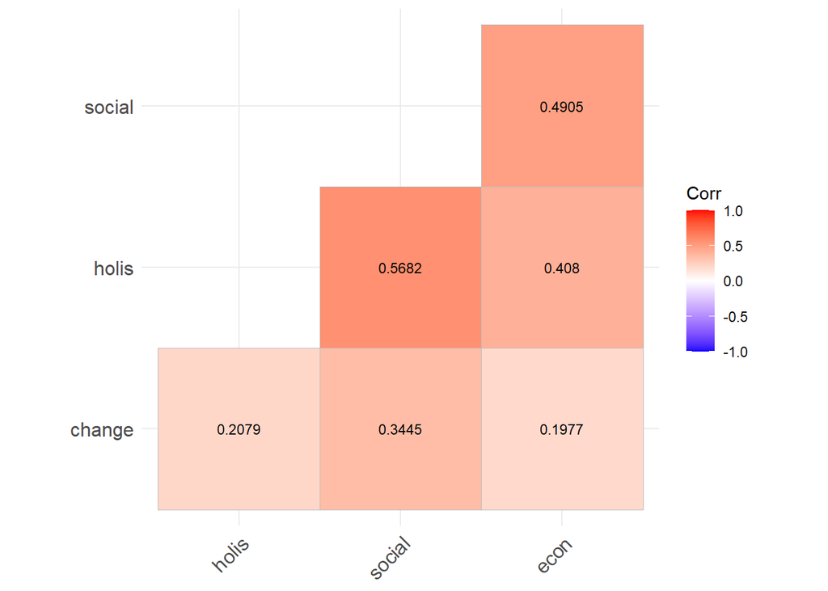

```r
p.mat <- cor_pmat(select(dfenc,change, holis:econ))
ggcorrplot(cor(select(dfenc,change, holis:econ)),
           type="lower",
           lab=TRUE,
           lab_size=3,
           insig="blank",
           p.mat=p.mat,
           digits=4,
           sig.level=0.10)
```

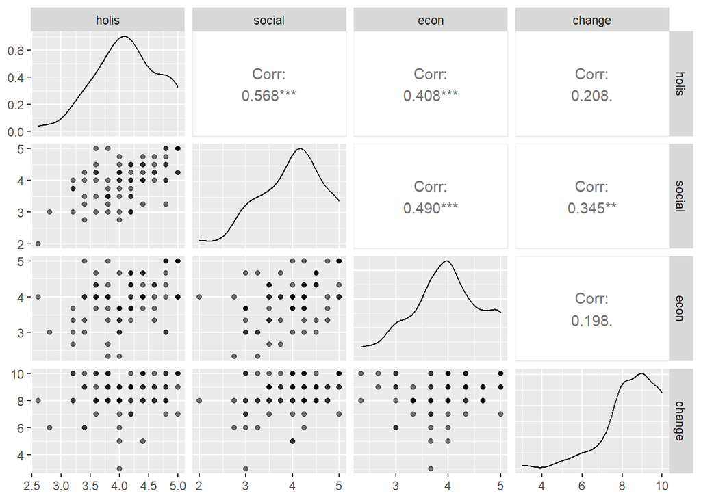

```r
ggpairs(select(dfenc,holis:econ, change), aes(alpha=0.1))
```

```r
model <- lm(change ~ campus + holis + social + econ, data=dfenc)
summary(model)
```

```
##
## Call:
## lm(formula = change ~ campus + holis + social + econ, data = dfenc)
##
## Residuals:
##     Min      1Q  Median      3Q     Max
## -4.8936 -0.5873  0.0947  0.8562  2.1273
##
## Coefficients:
##               Estimate Std. Error t value Pr(>|t|)
## (Intercept)     5.1072     1.1847   4.311 4.81e-05 ***
## campusOtro      0.5400     0.4726   1.143  0.25677
## campusSinaloa   0.8385     0.3608   2.324  0.02281 *
## holis          -0.1998     0.3381  -0.591  0.55631
## social          0.8901     0.2985   2.982  0.00385 **
## econ            0.1023     0.2514   0.407  0.68516
## ---
## Signif. codes:  0 '***' 0.001 '**' 0.01 '*' 0.05 '.' 0.1 ' ' 1
##
## Residual standard error: 1.282 on 76 degrees of freedom
## Multiple R-squared:  0.1807, Adjusted R-squared:  0.1267
## F-statistic: 3.351 on 5 and 76 DF,  p-value: 0.008659
```

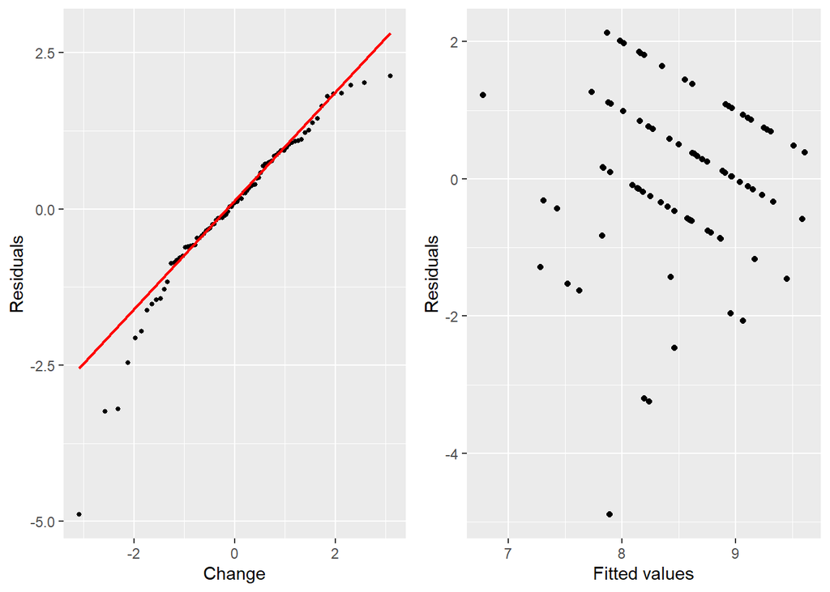

```r
# Residual analysis
p1 <- ggplot(mapping = aes(sample = residuals(model))) +
  stat_qq_point(size = 1, color="black") +
  stat_qq_line(color="red") +
  labs(x="Change", y = "Residuals")
p2 <- ggplot(model, aes(x=fitted(model), y=residuals(model))) +
  geom_point() +
  #geom_point(group=model$model$change, color=model$model$change) +
  labs(x="Fitted values", y="Residuals") +
  theme(legend.position = "top")
grid.arrange(p1, p2, nrow=1)
```

```r
# Kolmogorov-Smirnov test
ksout <- ks.test(residuals(model), "pnorm", mean=0, sd=sd(residuals(model)))
print(ksout)
```

```
##
##  Asymptotic one-sample Kolmogorov-Smirnov test
##
## data:  residuals(model)
## D = 0.10301, p-value = 0.349
## alternative hypothesis: two-sided
```

## 9 References

Okur-Berberoglu, E. (2020). An ecological intelligence scale intended for adults. World Futures, 76(3), 133-152.

Yves Rosseel (2012). lavaan: An R Package for Structural Equation Modeling. Journal of Statistical Software, 48(2), 1-36. URL http://www.jstatsoft.org/v48/i02/